# UCRP Full Override Model

# Opening slide

Model description:

- Actuarial liabilities, benefit payments, normal costs, employee contributions are drawn directly from Segal open plan projection.
- The model calculates UC contributions and plan asset values under stochastic investment return scenarios and various contribution policies.
- Important model settings:
  - UC contributions are no less than employee contributions (AV2015)
  - 20-year level dollar closed amortization.(amort basis occurred prior to 2015 are drawn from AV2015)
  - 5-year asset smoothing

# 1. Deterministic run with constant return of 7.25%; Segal projected contribution

## Finance Table ($million)

| year | AL | MA | B | C | EEC | ERC | extFund | netxcf | FR.MA | ERC_PR | netxcf_MA | apratio |
| --- | --- | --- | --- | --- | --- | --- | --- | --- | --- | --- | --- | --- |
| 2015 | 56433.24 | 46628.55 | 2984.90 | 2685.01 | 769.13 | 1352.35 | 563.53 | -299.89 | 82.63 | 14.00 | -0.64 | 4.83 |
| 2020 | 72003.94 | 62784.54 | 3706.02 | 2469.93 | 890.84 | 1579.09 | 0.00 | -1236.09 | 87.20 | 14.00 | -1.97 | 5.57 |
| 2025 | 89154.19 | 79527.03 | 4917.63 | 2879.20 | 1033.25 | 1845.95 | 0.00 | -2038.43 | 89.20 | 14.00 | -2.56 | 6.03 |
| 2030 | 107394.14 | 98271.71 | 6284.23 | 3364.93 | 1201.82 | 2163.11 | 0.00 | -2919.30 | 91.51 | 14.00 | -2.97 | 6.36 |
| 2035 | 126560.08 | 119450.38 | 7686.50 | 3945.65 | 1404.16 | 2541.49 | 0.00 | -3740.85 | 94.38 | 14.00 | -3.13 | 6.58 |
| 2040 | 147351.21 | 144592.51 | 9077.95 | 4639.58 | 1645.54 | 2994.03 | 0.00 | -4438.38 | 98.13 | 14.00 | -3.07 | 6.76 |
| 2044 | 166182.38 | 166903.40 | 10111.26 | 3823.26 | 1872.06 | 1951.21 | 0.00 | -6287.99 | 100.43 | 7.99 | -3.77 | 6.84 |

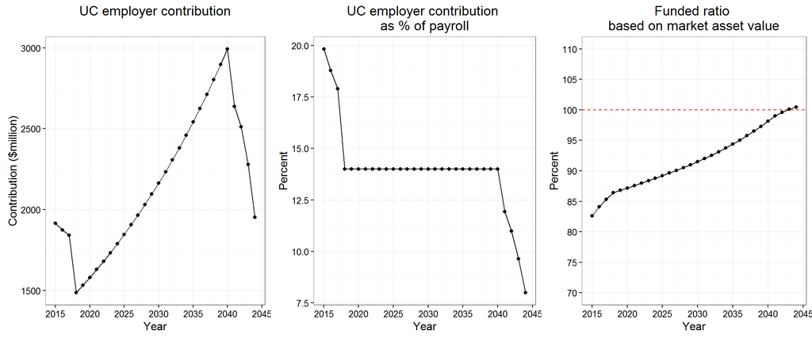

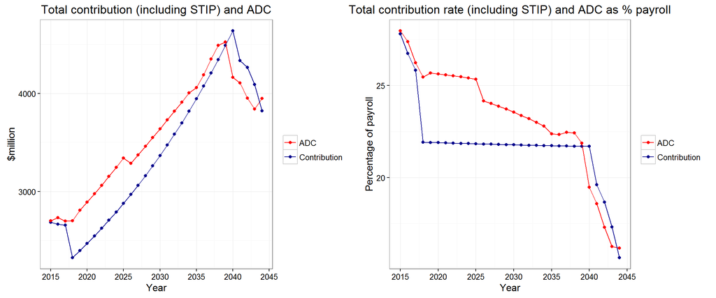

[output not shown]

# 2. Stochastic return with 7.25% mean long term compound return, Segal projected contribution

- Contribution Policy: use contributions from Segal projection
- In each simulation, returns are drawn from a normal distribution with mean 7.97% and standard deviation 12%, which implies an average long-term compound (geometric) return of 7.25%. The 25th and 75th percentiles of this return distribution are -0.12% and 16.1% respectively.

## Distribution of 30-year compound annual return over all simulations

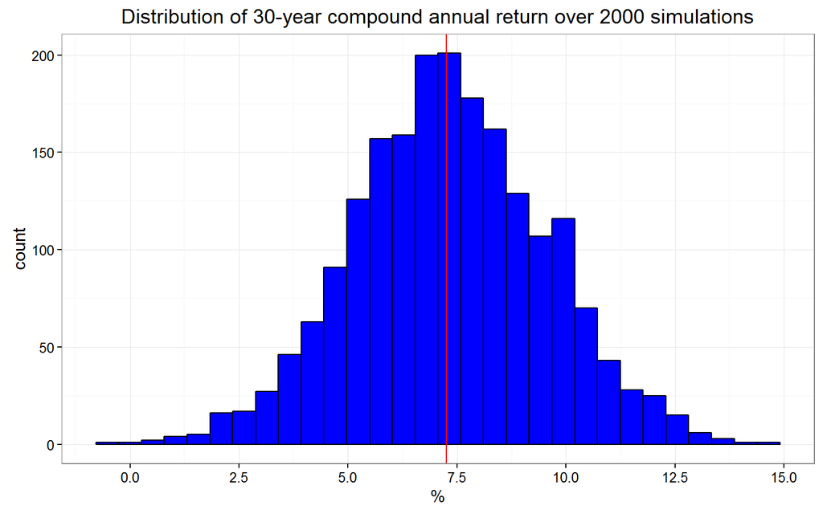

## Funded ratios over 30 years for selected individual simulations

- Two simulations with compound annual return at year 30 close to 7.25%. (Blue lines)
- Two simulations with compound annual returns at 25th percentile (Red) and 75th percentile (Green) respectively over all simulations.

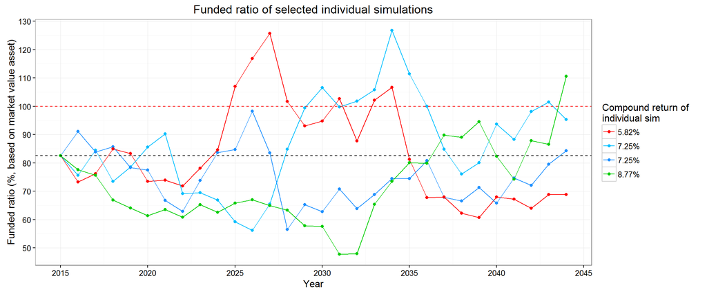

## Probability of funded ratio falling below 40% and rising above 95%

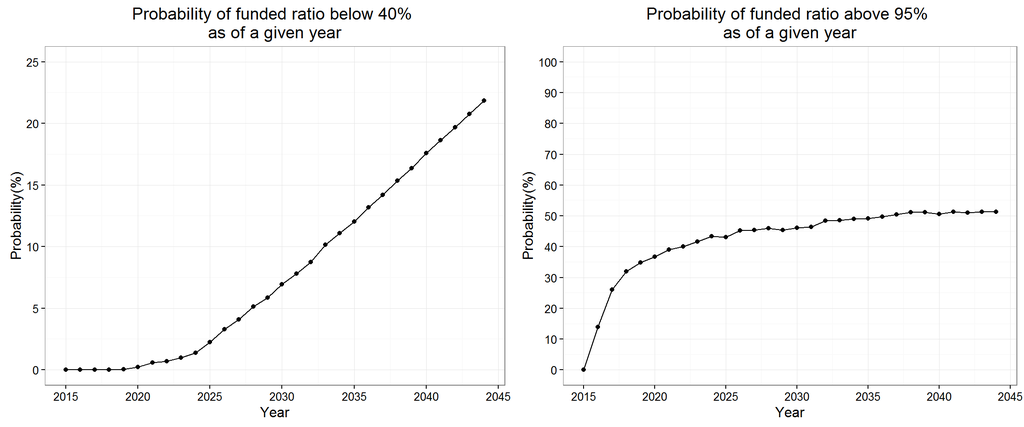

## Median UC contribution (including STIP) over all simulations

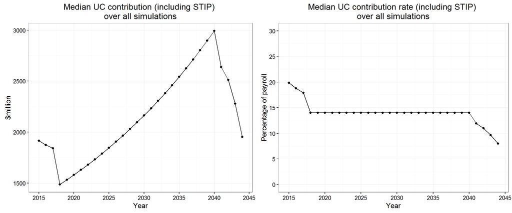

## Total Contribution

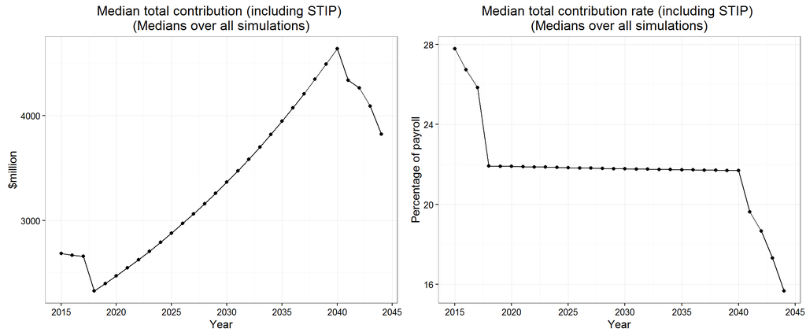

## Total Contribution compared to ADC

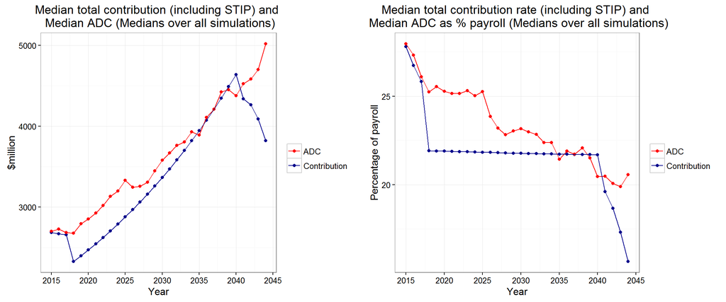

## Table of summary results

| year | FR95more | FR40less | FR.q25 | FR.med | ERCwSTIP_PR.med |
| --- | --- | --- | --- | --- | --- |
| 2015 | 0.00 | 0.00 | 82.626 | 82.626 | 19.834 |
| 2020 | 36.80 | 0.25 | 73.419 | 87.153 | 14.000 |
| 2025 | 43.10 | 2.25 | 68.409 | 89.690 | 14.000 |
| 2030 | 46.15 | 6.95 | 65.385 | 90.826 | 14.000 |
| 2035 | 49.20 | 12.05 | 58.909 | 94.036 | 14.000 |
| 2040 | 50.60 | 17.60 | 52.115 | 96.347 | 14.000 |
| 2044 | 51.25 | 21.85 | 46.532 | 97.495 | 7.992 |

# 3. Stochastic return with 7.25% mean long term compound return, total contribution cannot be less than ADC

- Contribution policy:
  - Employer contributions from Segal projection.
  - Employer contributions are no less than employee contributions.(The minimum total contribution is 2*employee contribution)
  - Employee contributions + employer contributions + STIP = ADC, unless ADC < 2*employee contribution.
- In each simulation, returns are drawn from a normal distribution with mean 7.97% and standard deviation 12%, which implies an average long-term compound (geometric) return of 7.25%. The 25th and 75th percentiles of this return distribution are -0.12% and 16.1% respectively.

## Funded ratios over 30 years for selected individual simulations

- Two simulations with compound annual return close to 7.25%.(Blue lines)
- Two simulations with compound annual returns at 25th percentile(Red) and 75th percentile(Green) respectively over all simulations

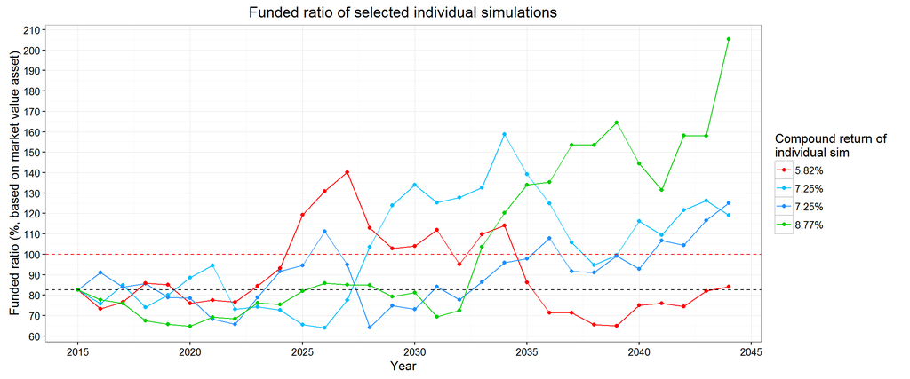

## Probability of funded ratio falling below 40% or rising above 95%

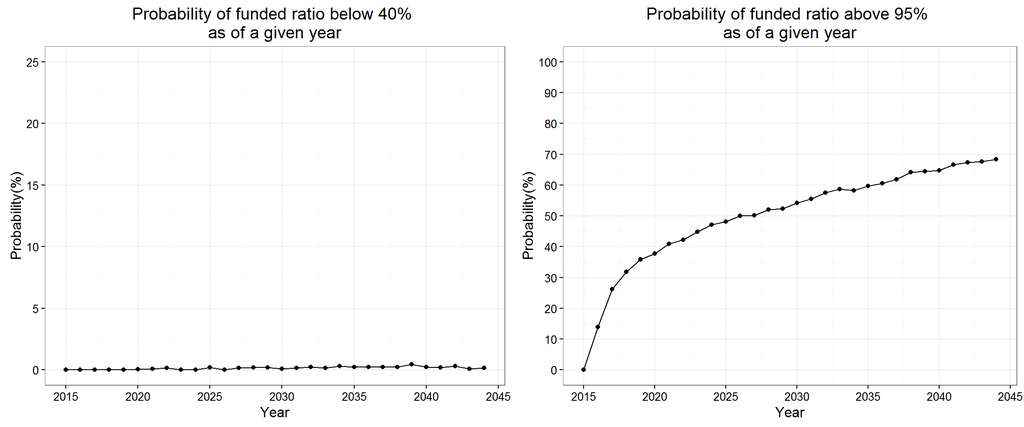

## Median UC contribution (including STIP) over all simulations

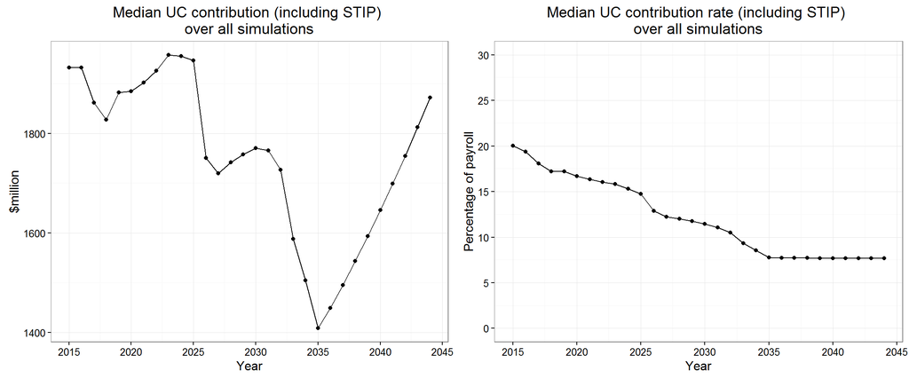

## Total Contribution compared to ADC

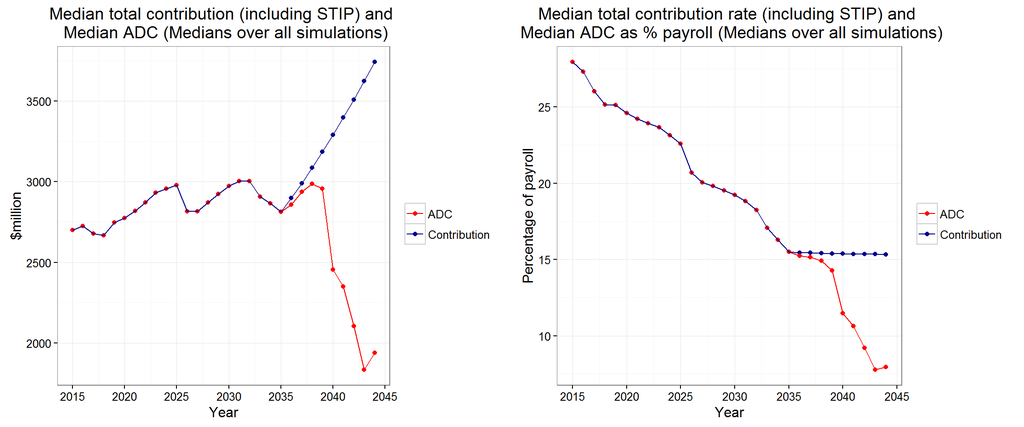

## Table of summary results

| year | FR95more | FR40less | FR.q25 | FR.med | ERCwSTIP_PR.med |
| --- | --- | --- | --- | --- | --- |
| 2015 | 0.00 | 0.00 | 82.626 | 82.626 | 20.006 |
| 2020 | 37.80 | 0.05 | 75.781 | 88.561 | 16.711 |
| 2025 | 48.15 | 0.20 | 76.368 | 93.729 | 14.760 |
| 2030 | 54.20 | 0.10 | 79.419 | 98.499 | 11.459 |
| 2035 | 59.70 | 0.25 | 81.535 | 103.853 | 7.759 |
| 2040 | 64.80 | 0.25 | 84.974 | 112.587 | 7.695 |
| 2044 | 68.35 | 0.15 | 87.481 | 120.047 | 7.668 |

# 4. Stochastic return with higher and lower mean compound returns, Segal projected contributions

- Contribution policy: the same as in section 2.
- Three model runs (2000 individual runs in each) with following return distributions:
  - Left: mean=5.97%, sd=12% (mean long-term compound return 5.25%)
  - Middle: mean=7.97%, sd=12% (mean long-term compound return 7.25%)
  - Right: mean=9.97%, sd=12% (mean long-term compound return 9.25%)

Note: For model with mean return 5.97%, the probabilities of funded ratio falling below 40% in selected years after 2030 are 34.24%(2035), 45.85%(2040), 54.65%(2044).

## Probability of funded ratio falling below 40%

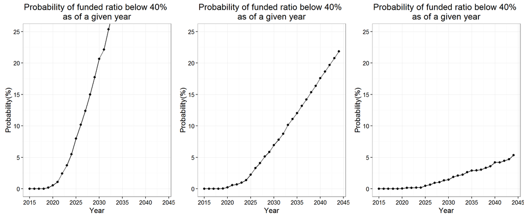

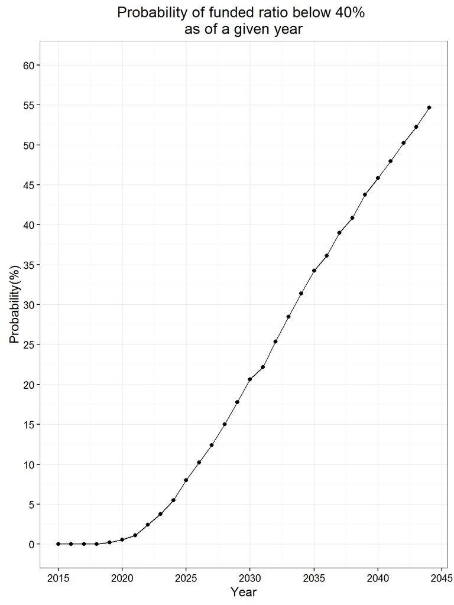

## Probability of funded ratio rising above 95%

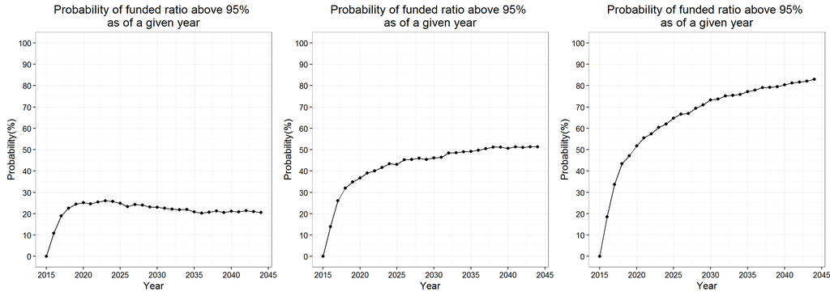

## Median UC contribution (including STIP) rate over all simulations

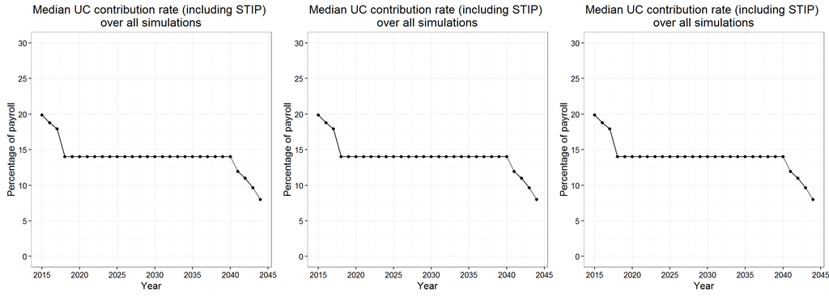

# 5. Stochastic return with higher and lower mean compound returns, total contributions no less than ADC

- Contribution policy: the same as in section 3.
- Three model runs (2000 individual runs in each) with following return distributions:
  - Left: mean=5.97%, sd=12% (mean long-term compound return 5.25%)
  - Middle: mean=7.97%, sd=12% (mean long-term compound return 7.25%)
  - Right: mean=9.97%, sd=12% (mean long-term compound return 9.25%)

## Probability of funded ratio falling below 40%

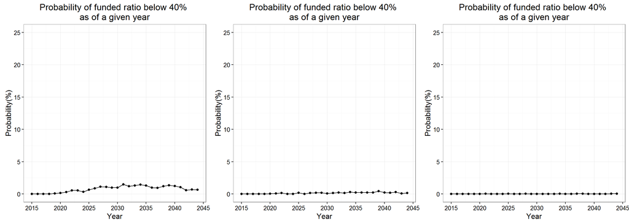

## Probability of funded ratio rising above 95%

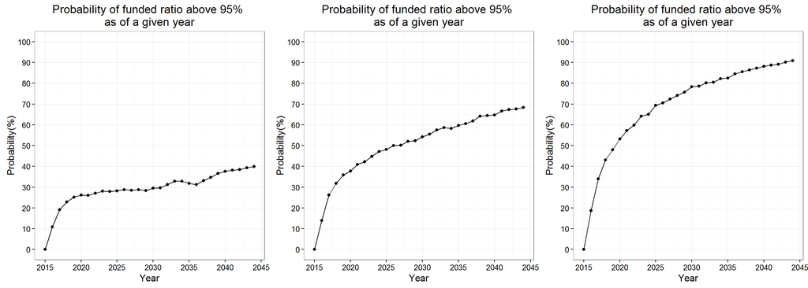

## Median UC contribution (including STIP) rate over all simulations

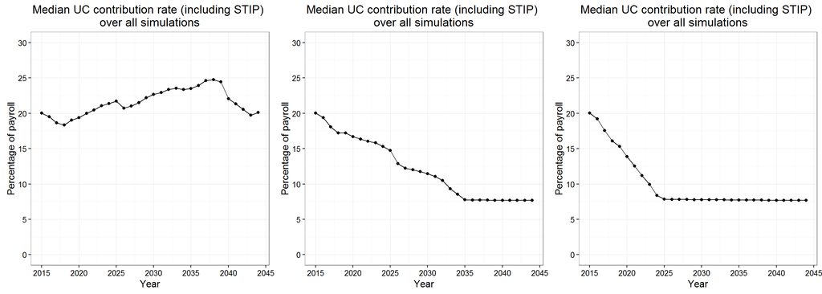

# 6. Stochastic return with higher and lower mean compound returns, total contributions no less than ADC

- Contribution policy: policy in section 5 + 14% cap on ERC rate.
- Three model runs (2000 individual runs in each) with following return distributions:
  - Left: mean=5.97%, sd=12% (mean long-term compound return 5.25%)
  - Middle: mean=7.97%, sd=12% (mean long-term compound return 7.25%)
  - Right: mean=9.97%, sd=12% (mean long-term compound return 9.25%)

## Probability of funded ratio falling below 40%

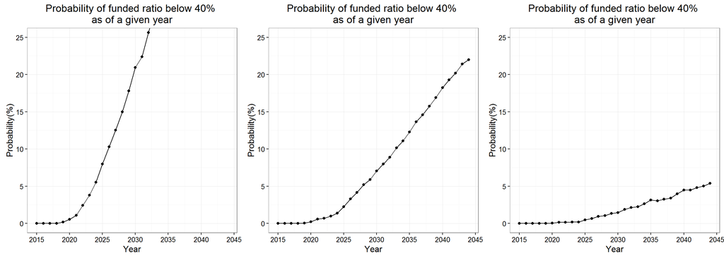

## Probability of funded ratio rising above 95%

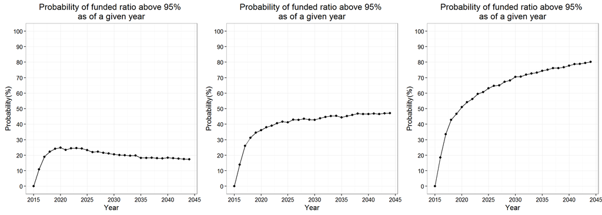

## Median UC contribution (including STIP) rate over all simulations

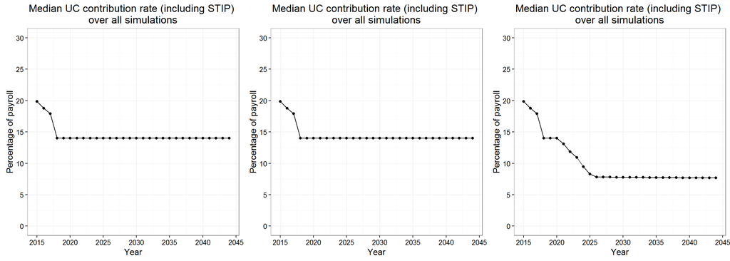